# Weak Law of Large Numbers

September 20, 2016

## Random Variable

- A random variable is often denoted \(X\)
- We don't know its value a priori, but we can characterize its behavior via its **distribution**
  - Describes relative frequency with which values occur
  - AUC = 1 = 100%

## Distribution

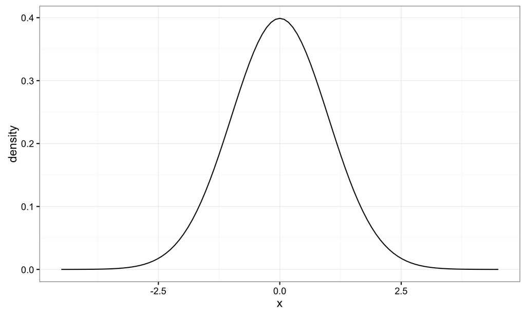

## Further Characterizations

Its mean \(\mu\) and standard deviation \(\sigma\).

[figure not shown]

## Sample Mean

- We need to distinguish the true mean \(\mu\)
- From the **sample mean** based on a sample \(X_1, \ldots, X_n\): \(\overline{X}_n = \frac{1}{n}\sum_{i=1}^{n}X_i\)
- **Moral of the Story**: \(\overline{X}_n\) estimates \(\mu\)

## Weak Law of Large Numbers

## Convergence in Probability

For a given \(\epsilon\) and \(n\)

- Let \(X\) have \(\mu=0\)
- Based on a sample \(X_1, \ldots, X_n\) of size \(n\), compute \(\overline{X}_n\)
- Do this a bunch of times to see how \(\overline{X}_n\) varies from sample to sample

## Convergence in Probability

Recall \(\mu=0\). For \(\epsilon=0.1\)

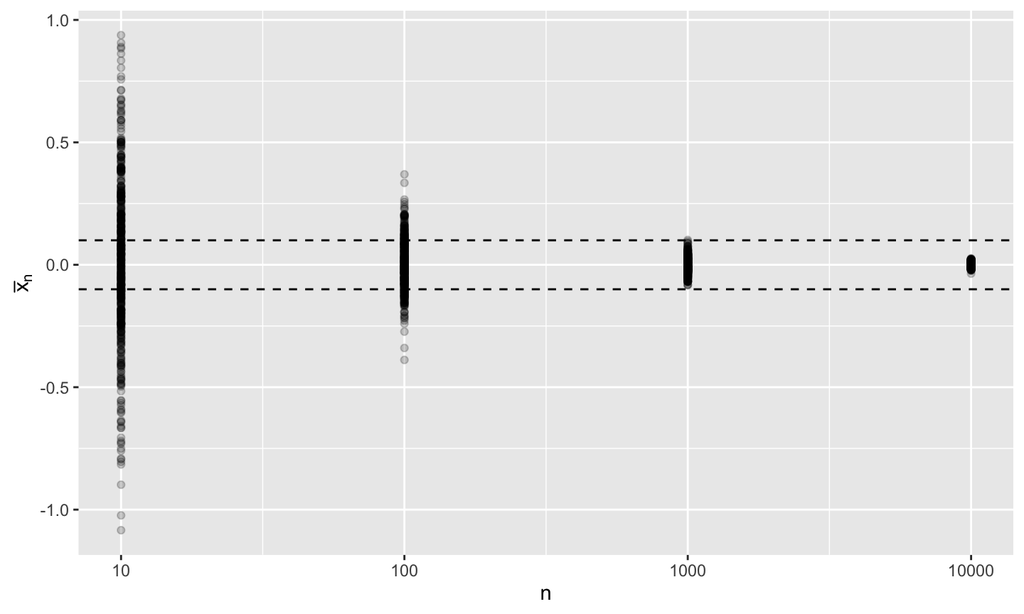

## Chebyshev's Inequality

Normal RV with \(\mu=0\) and \(\sigma=1\)

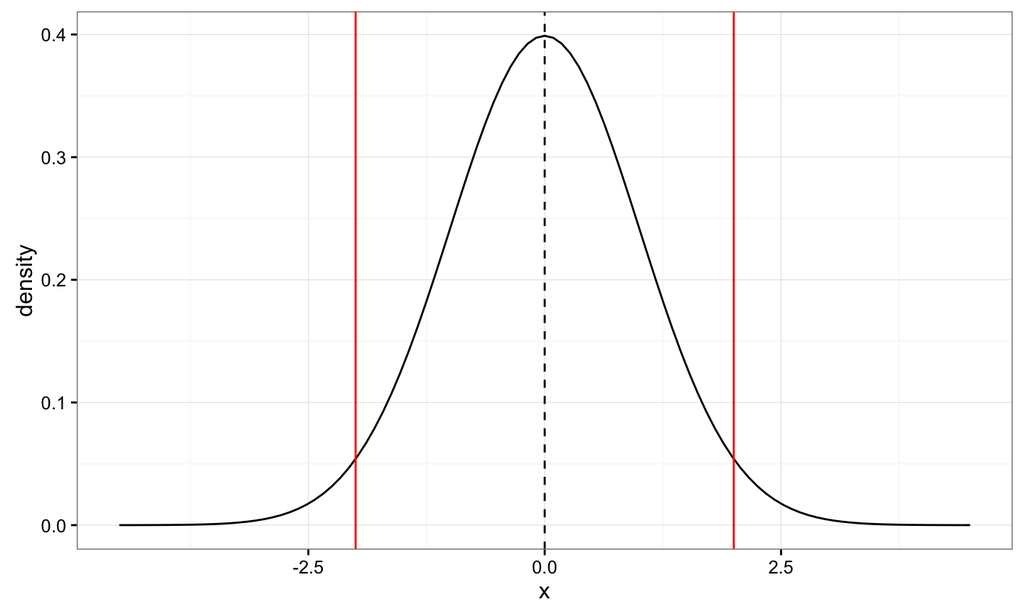

## Chebyshev's Inequality

Gamma RV with \(\mu=\) 1.25 and \(\sigma=\) 0.559

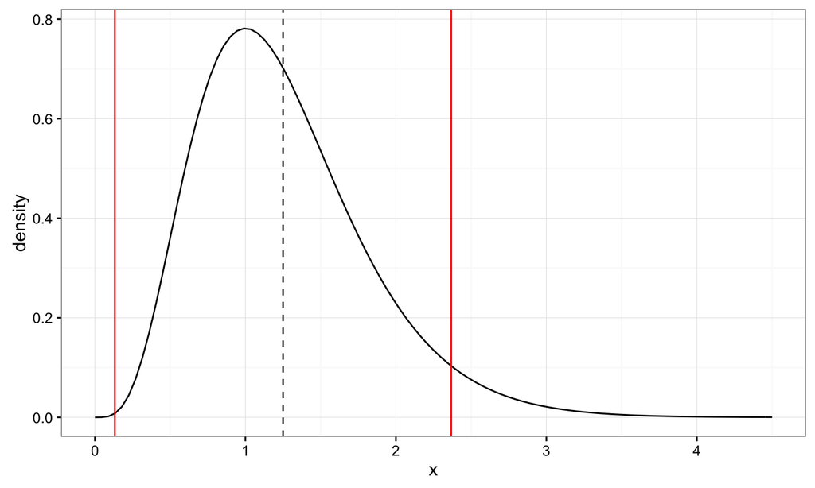